# Week 10: Analysis - House Selling Prices

```r
library(tidyverse)
library(mosaic)
library(pander)
library(readxl)
library(ggplot2)
library(dplyr)
library(plotly)
library(reshape2)

HousesData <- read.csv("train.csv", stringsAsFactors = TRUE)
```

```r
# All the mutate statements
HousesData <- HousesData %>%
  mutate(Alley = as.character(Alley),
         Alley = replace_na(Alley, "None"),
         Alley = as.factor(Alley))

#Or use mutate and create a new "TotalSF" variable that allows for a simple linear regression model that is just as powerful, but far easier to graph and interpret.
HousesData <- HousesData %>%
  mutate(TotalSF = X1stFlrSF + X2ndFlrSF + TotalBsmtSF)

#Notice as well how mutate can be used to change complicated variables into simple on-off switches.
HousesData <- HousesData %>%
  mutate(TotalSF = X1stFlrSF + X2ndFlrSF + TotalBsmtSF,
                RichNbrhd = case_when(Neighborhood %in% c("StoneBr", "NridgHt", "NoRidge") ~ 1, TRUE ~ 0),
         KitchenQual2 = case_when(KitchenQual %in% c("Ex","Gd") ~ 2,
                                 KitchenQual %in% c("TA", "Fa") ~ 1,
                                 KitchenQual == "Po" ~ 0))
```

For this week’s analysis, we worked with a “friendly competition” data sets from Kaggle.com about predicting final sales prices for houses, based on 79 available explanatory variables categorising and describing most aspects of residential houses in Ames, Iowa.

## My lm

I based some of this lm model on what we had already done in class and the other x variables came from the pairs plots while looking for any kind of notable slope. (For obvious reasons of size, I did not include the actual pairs plot in here.) After some trial and error I found `GarageArea`, `GrLivArea`, `TotRmsAbvGrd`, `KitchenQual` which I relabelled as `KitchenQual2` but without any actual change in information, and `OverallQual` as viable enough x variables.

```r
lm.con <- lm(data=HousesData, SalePrice ~ RichNbrhd + TotalSF:RichNbrhd + GarageArea + GrLivArea + TotalSF:GrLivArea + RichNbrhd:TotRmsAbvGrd + as.factor(KitchenQual2):TotalSF + OverallQual + OverallQual:TotalSF)

pander(summary(lm.con))
```

Table continues below

|  | Estimate | Std. Error | t value |
| --- | --- | --- | --- |
| **(Intercept)** | 18073 | 6258 | 2.888 |
| **RichNbrhd** | -197197 | 13588 | -14.51 |
| **GarageArea** | 39.05 | 4.78 | 8.17 |
| **GrLivArea** | 68.33 | 3.842 | 17.78 |
| **OverallQual** | -6205 | 1812 | -3.425 |
| **RichNbrhd:TotalSF** | 51.59 | 4.507 | 11.45 |
| **TotalSF:GrLivArea** | -0.01903 | 0.001113 | -17.09 |
| **RichNbrhd:TotRmsAbvGrd** | 6647 | 1935 | 3.435 |
| **TotalSF:as.factor(KitchenQual2)2** | 7.009 | 0.7953 | 8.813 |
| **TotalSF:OverallQual** | 8.9 | 0.5509 | 16.15 |

|  | Pr(>\|t\|) |
| --- | --- |
| **(Intercept)** | 0.003932 |
| **RichNbrhd** | 1.163e-44 |
| **GarageArea** | 6.65e-16 |
| **GrLivArea** | 3.703e-64 |
| **OverallQual** | 0.000633 |
| **RichNbrhd:TotalSF** | 4.151e-29 |
| **TotalSF:GrLivArea** | 7.966e-60 |
| **RichNbrhd:TotRmsAbvGrd** | 0.0006101 |
| **TotalSF:as.factor(KitchenQual2)2** | 3.42e-18 |
| **TotalSF:OverallQual** | 4.168e-54 |

Fitting linear model: SalePrice ~ RichNbrhd + TotalSF:RichNbrhd + GarageArea + GrLivArea + TotalSF:GrLivArea + RichNbrhd:TotRmsAbvGrd + as.factor(KitchenQual2):TotalSF + OverallQual + OverallQual:TotalSF

| Observations | Residual Std. Error | $R^2$ | Adjusted $R^2$ |
| --- | --- | --- | --- |
| 1460 | 30107 | 0.8573 | 0.8564 |

## Drawing the models

I wasn’t sure how to present this kind of regression model, what would be considered irrelevant or excessive to draw, so I tried drawing enough plots to have all the interactions represented. If there is a better approach, I am open to suggestions.

As an overall trend, some extreme outliers in the upper regions (extreme high numbers, be it number of rooms or square feet of living space) might influence the accuracy of the model, or some aspect of it.

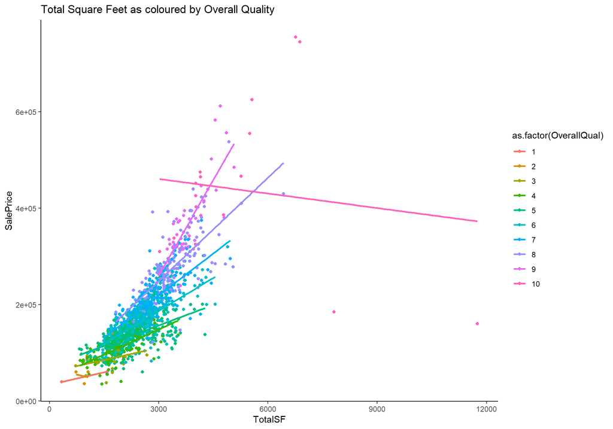

```r
#TotalSf with OverallQual
ggplot(HousesData, aes(x=TotalSF, y=SalePrice, color=as.factor(OverallQual))) +
  geom_point(pch=16) +
  geom_smooth(method="lm", formula=y~x, se=F) +
  labs(title="Total Square Feet as coloured by Overall Quality") +
theme_classic()
```

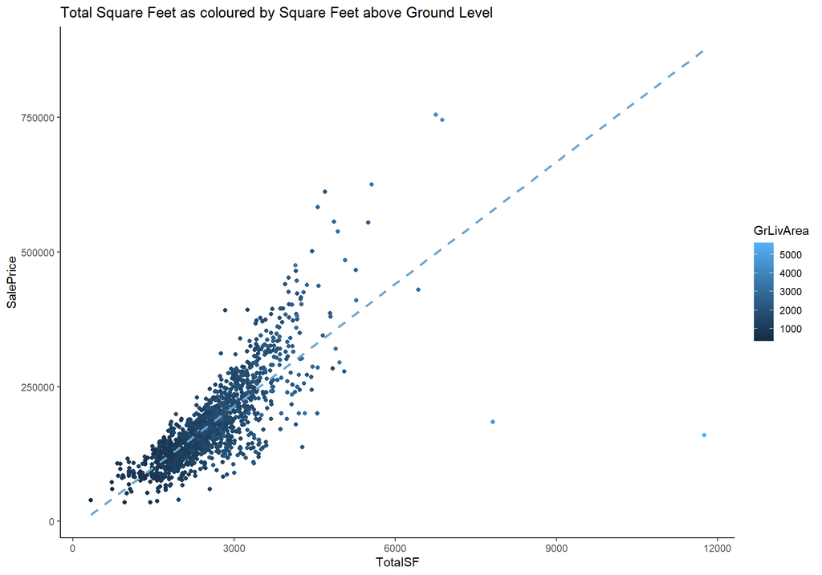

```r
#TotalSf with GrLivArea
ggplot(HousesData, aes(x=TotalSF, y=SalePrice, color=GrLivArea)) +
  geom_point(pch=16) +
  geom_smooth(method="lm", formula=y~x, se=F, color="skyblue3", lty=2) +
  labs(title="Total Square Feet as coloured by Square Feet above Ground Level") +
theme_classic()
```

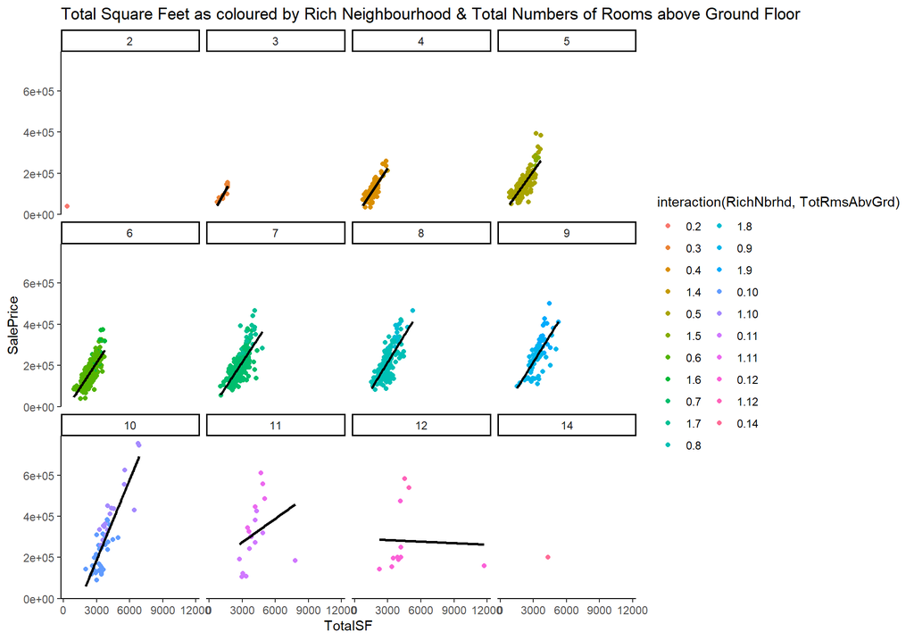

```r
#TotalSf with RichNbrhd & TotRmsAbvGrad
ggplot(HousesData, aes(x=TotalSF, y=SalePrice, color=interaction(RichNbrhd, TotRmsAbvGrd))) +
  geom_point(pch=16) +
  geom_smooth(method="lm", formula=y~x, se=F, color="black", alpha=0.25) +
  facet_wrap(~TotRmsAbvGrd) +
  labs(title="Total Square Feet as coloured by Rich Neighbourhood & Total Numbers of Rooms above Ground Floor") +
theme_classic()
```

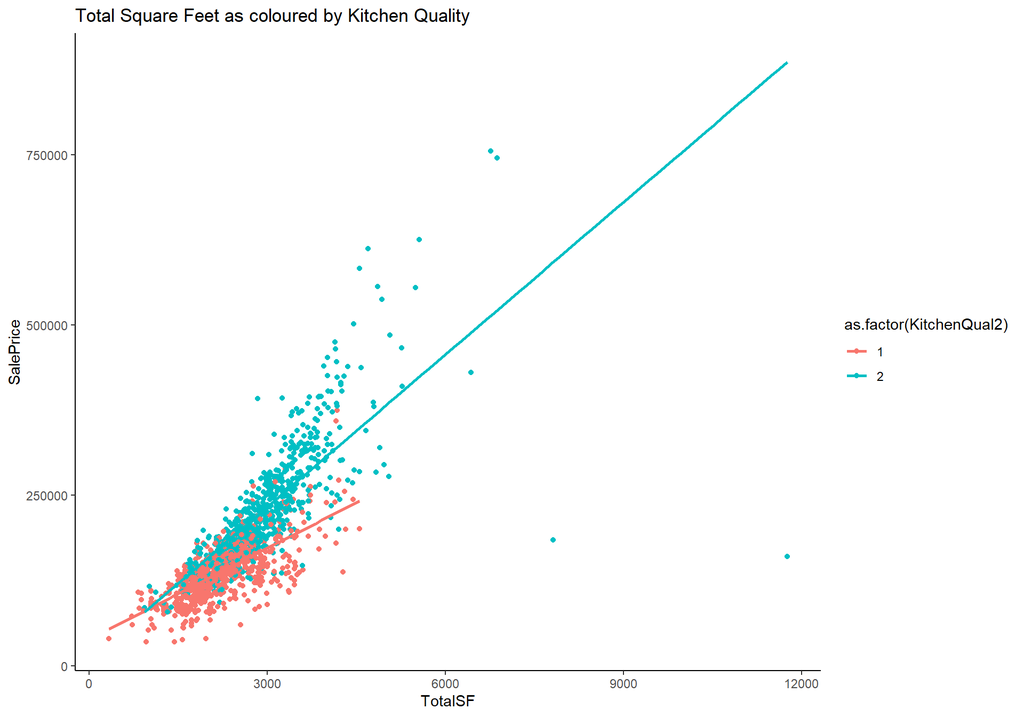

```r
#TotalSf with KitchenQual2
ggplot(HousesData, aes(x=TotalSF, y=SalePrice, color=as.factor(KitchenQual2))) +
  geom_point(pch=16) +
  geom_smooth(method="lm", formula=y~x, se=F) +
  labs(title="Total Square Feet as coloured by Kitchen Quality") +
theme_classic()
```

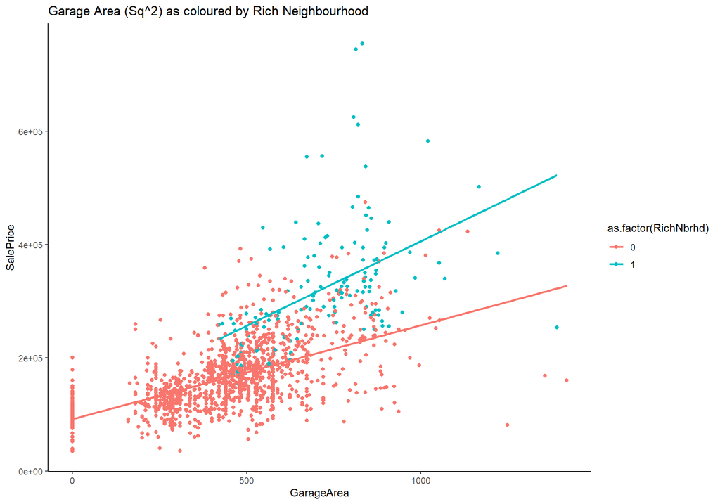

```r
#GarageArea with RichNbrhd
ggplot(HousesData, aes(x=GarageArea, y=SalePrice, color=as.factor(RichNbrhd))) +
  geom_point(pch=16) +
  geom_smooth(method="lm", formula=y~x, se=F) +
  labs(title="Garage Area (Sq^2) as coloured by Rich Neighbourhood") +
theme_classic()
```

## Data Validation

```r
set.seed(121)
num_rows <- 1000 # 1460 total
keep <- sample(1:nrow(HousesData), num_rows)

mytrain <- HousesData[keep, ] #Use this in the lm(..., data=mytrain) it is like "rbdata"

mytest <- HousesData[-keep, ] #Use this in the predict(..., newdata=mytest) it is like "rbdata2"

lm.con <- lm(data=mytrain, SalePrice ~ RichNbrhd + TotalSF:RichNbrhd + GarageArea + GrLivArea + TotalSF:GrLivArea + RichNbrhd:TotRmsAbvGrd + as.factor(KitchenQual2):TotalSF + OverallQual + OverallQual:TotalSF)

# Validation set-up
yh_con <- predict(lm.con, newdata=mytest)
ybar <- mean(mytest$SalePrice)

SSTO <- sum( (mytest$SalePrice - ybar)^2 )
SSE_con <- sum( (mytest$SalePrice - yh_con)^2 )

rs_con <- 1 - SSE_con/SSTO

n <- nrow(mytest)
p_con <- length(lm.con)

rsa_con <- 1 - (n-1)/(n-p_con)*SSE_con/SSTO
```

```r
my_output_table <- data.frame(Model = "Model Validation",
                                 `Original R2` = summary(lm.con)$r.squared,
                                 `Orig. Adj. R-squared` = summary(lm.con)$adj.r.squared,
                                 `Validation R-squared` = rs_con,
                                 `Validation Adj. R^2` = rsa_con)

colnames(my_output_table) <- c("Model", "Original $R^2$", "Original Adj. $R^2$", "Validation $R^2$", "Validation Adj. $R^2$")

knitr::kable(my_output_table, escape=TRUE, digits=4)
```

| Model | Original $R^2$ | Original Adj. $R^2$ | Validation $R^2$ | Validation Adj. $R^2$ |
| --- | --- | --- | --- | --- |
| Model Validation | 0.8633 | 0.8621 | 0.8351 | 0.8307 |

```r
summary(lm.con)
```

```
##
## Call:
## lm(formula = SalePrice ~ RichNbrhd + TotalSF:RichNbrhd + GarageArea +
##     GrLivArea + TotalSF:GrLivArea + RichNbrhd:TotRmsAbvGrd +
##     as.factor(KitchenQual2):TotalSF + OverallQual + OverallQual:TotalSF,
##     data = mytrain)
##
## Residuals:
##     Min      1Q  Median      3Q     Max
## -212170  -14791    -189   14315  146271
##
## Coefficients:
##                                    Estimate Std. Error t value Pr(>|t|)
## (Intercept)                       1.911e+04  7.697e+03   2.483 0.013199 *
## RichNbrhd                        -1.937e+05  1.663e+04 -11.647  < 2e-16 ***
## GarageArea                        4.761e+01  6.036e+00   7.887 8.14e-15 ***
## GrLivArea                         5.427e+01  6.384e+00   8.501  < 2e-16 ***
## OverallQual                      -3.845e+03  2.243e+03  -1.714 0.086795 .
## RichNbrhd:TotalSF                 4.680e+01  5.503e+00   8.504  < 2e-16 ***
## TotalSF:GrLivArea                -1.554e-02  1.840e-03  -8.446  < 2e-16 ***
## RichNbrhd:TotRmsAbvGrd            8.129e+03  2.207e+03   3.684 0.000242 ***
## TotalSF:as.factor(KitchenQual2)2  7.070e+00  9.721e-01   7.273 7.15e-13 ***
## TotalSF:OverallQual               8.100e+00  6.868e-01  11.794  < 2e-16 ***
## ---
## Signif. codes:  0 '***' 0.001 '**' 0.01 '*' 0.05 '.' 0.1 ' ' 1
##
## Residual standard error: 30150 on 990 degrees of freedom
## Multiple R-squared:  0.8633, Adjusted R-squared:  0.8621
## F-statistic: 694.7 on 9 and 990 DF,  p-value: < 2.2e-16
```

## Show your work - Class Stuff

I wasn’t sure what was meant by ‘show your work’ and since I still had the class notes here I just left them.

```r
# plot(data=HousesData, SalePrice ~ Neighborhood, las=2)
#
# myhouse.lm <- lm(data=HousesData, SalePrice ~ Neighbourhood)
# summary(myhouse.lm)

# lm.alley <- lm(SalePrice ~ Alley, data=HousesData)
# summary(lm.alley) --> Almost all observations are missing bc NA was used as an informational option (which is what the mutate statement is for)
# lm.fence <- lm(SalePrice ~ Fence, data=HousesData)
# summary(lm.fence)

lm.1stflr <- lm(SalePrice ~ X1stFlrSF, data=HousesData)
summary(lm.1stflr)
```

```
##
## Call:
## lm(formula = SalePrice ~ X1stFlrSF, data = HousesData)
##
## Residuals:
##     Min      1Q  Median      3Q     Max
## -460330  -36494  -13164   36291  414547
##
## Coefficients:
##              Estimate Std. Error t value Pr(>|t|)
## (Intercept) 36173.447   5245.728   6.896 7.95e-12 ***
## X1stFlrSF     124.501      4.282  29.078  < 2e-16 ***
## ---
## Signif. codes:  0 '***' 0.001 '**' 0.01 '*' 0.05 '.' 0.1 ' ' 1
##
## Residual standard error: 63220 on 1458 degrees of freedom
## Multiple R-squared:  0.3671, Adjusted R-squared:  0.3666
## F-statistic: 845.5 on 1 and 1458 DF,  p-value: < 2.2e-16
```

```r
lm.2ndflr <- lm(SalePrice ~ X2ndFlrSF, data=HousesData)
summary(lm.2ndflr)
```

```
##
## Call:
## lm(formula = SalePrice ~ X2ndFlrSF, data = HousesData)
##
## Residuals:
##     Min      1Q  Median      3Q     Max
## -159576  -45756  -17756   27144  485454
##
## Coefficients:
##              Estimate Std. Error t value Pr(>|t|)
## (Intercept) 1.608e+05  2.518e+03   63.84   <2e-16 ***
## X2ndFlrSF   5.812e+01  4.517e+00   12.87   <2e-16 ***
## ---
## Signif. codes:  0 '***' 0.001 '**' 0.01 '*' 0.05 '.' 0.1 ' ' 1
##
## Residual standard error: 75310 on 1458 degrees of freedom
## Multiple R-squared:  0.102,  Adjusted R-squared:  0.1014
## F-statistic: 165.6 on 1 and 1458 DF,  p-value: < 2.2e-16
```

```r
lm.basement <- lm(SalePrice ~ TotalBsmtSF, data=HousesData)
summary(lm.basement)
```

```
##
## Call:
## lm(formula = SalePrice ~ TotalBsmtSF, data = HousesData)
##
## Residuals:
##     Min      1Q  Median      3Q     Max
## -582310  -39612  -14095   33315  420018
##
## Coefficients:
##              Estimate Std. Error t value Pr(>|t|)
## (Intercept) 63430.629   4286.892   14.80   <2e-16 ***
## TotalBsmtSF   111.110      3.745   29.67   <2e-16 ***
## ---
## Signif. codes:  0 '***' 0.001 '**' 0.01 '*' 0.05 '.' 0.1 ' ' 1
##
## Residual standard error: 62750 on 1458 degrees of freedom
## Multiple R-squared:  0.3765, Adjusted R-squared:  0.3761
## F-statistic: 880.3 on 1 and 1458 DF,  p-value: < 2.2e-16
```

```r
#Put them all together into a high dimensional multiple regression model

lm.sqft.all <- lm(SalePrice ~ X1stFlrSF + X2ndFlrSF + TotalBsmtSF, data=HousesData)
summary(lm.sqft.all)
```

```
##
## Call:
## lm(formula = SalePrice ~ X1stFlrSF + X2ndFlrSF + TotalBsmtSF,
##     data = HousesData)
##
## Residuals:
##     Min      1Q  Median      3Q     Max
## -697622  -21631    -366   20427  276895
##
## Coefficients:
##               Estimate Std. Error t value Pr(>|t|)
## (Intercept) -14033.593   4492.048  -3.124  0.00182 **
## X1stFlrSF       81.786      5.861  13.955  < 2e-16 ***
## X2ndFlrSF       84.493      3.021  27.973  < 2e-16 ***
## TotalBsmtSF     66.718      5.136  12.990  < 2e-16 ***
## ---
## Signif. codes:  0 '***' 0.001 '**' 0.01 '*' 0.05 '.' 0.1 ' ' 1
##
## Residual standard error: 49310 on 1456 degrees of freedom
## Multiple R-squared:  0.6155, Adjusted R-squared:  0.6147
## F-statistic: 776.8 on 3 and 1456 DF,  p-value: < 2.2e-16
```

```r
lm.sqft <- lm(SalePrice ~ TotalSF, data=HousesData)
summary(lm.sqft)
```

```
##
## Call:
## lm(formula = SalePrice ~ TotalSF, data = HousesData)
##
## Residuals:
##     Min      1Q  Median      3Q     Max
## -715562  -22190    -669   20711  269879
##
## Coefficients:
##               Estimate Std. Error t value Pr(>|t|)
## (Intercept) -13219.802   4251.189   -3.11  0.00191 **
## TotalSF         75.628      1.577   47.95  < 2e-16 ***
## ---
## Signif. codes:  0 '***' 0.001 '**' 0.01 '*' 0.05 '.' 0.1 ' ' 1
##
## Residual standard error: 49510 on 1458 degrees of freedom
## Multiple R-squared:  0.6119, Adjusted R-squared:  0.6117
## F-statistic:  2299 on 1 and 1458 DF,  p-value: < 2.2e-16
```

```r
lm.sqft.rich <- lm(SalePrice ~ TotalSF + RichNbrhd + TotalSF:RichNbrhd, data=HousesData)
summary(lm.sqft.rich)
```

```
##
## Call:
## lm(formula = SalePrice ~ TotalSF + RichNbrhd + TotalSF:RichNbrhd,
##     data = HousesData)
##
## Residuals:
##     Min      1Q  Median      3Q     Max
## -532130  -21090    -866   20892  213493
##
## Coefficients:
##                     Estimate Std. Error t value Pr(>|t|)
## (Intercept)        2.704e+04  4.078e+03   6.630 4.73e-11 ***
## TotalSF            5.659e+01  1.594e+00  35.504  < 2e-16 ***
## RichNbrhd         -1.207e+05  1.695e+04  -7.122 1.66e-12 ***
## TotalSF:RichNbrhd  5.735e+01  4.696e+00  12.212  < 2e-16 ***
## ---
## Signif. codes:  0 '***' 0.001 '**' 0.01 '*' 0.05 '.' 0.1 ' ' 1
##
## Residual standard error: 42500 on 1456 degrees of freedom
## Multiple R-squared:  0.7143, Adjusted R-squared:  0.7137
## F-statistic:  1214 on 3 and 1456 DF,  p-value: < 2.2e-16
```

```r
#Transformation
lm.sqft.rich.log <- lm(log(SalePrice) ~ TotalSF + RichNbrhd + TotalSF:RichNbrhd, data=HousesData)
summary(lm.sqft.rich.log)
```

```
##
## Call:
## lm(formula = log(SalePrice) ~ TotalSF + RichNbrhd + TotalSF:RichNbrhd,
##     data = HousesData)
##
## Residuals:
##      Min       1Q   Median       3Q      Max
## -3.10832 -0.11267  0.02898  0.15067  0.65215
##
## Coefficients:
##                     Estimate Std. Error t value Pr(>|t|)
## (Intercept)        1.113e+01  2.308e-02 482.303  < 2e-16 ***
## TotalSF            3.368e-04  9.021e-06  37.337  < 2e-16 ***
## RichNbrhd          3.184e-01  9.594e-02   3.318 0.000928 ***
## TotalSF:RichNbrhd -1.279e-05  2.658e-05  -0.481 0.630441
## ---
## Signif. codes:  0 '***' 0.001 '**' 0.01 '*' 0.05 '.' 0.1 ' ' 1
##
## Residual standard error: 0.2406 on 1456 degrees of freedom
## Multiple R-squared:  0.6381, Adjusted R-squared:  0.6373
## F-statistic: 855.7 on 3 and 1456 DF,  p-value: < 2.2e-16
```

```r
exp(coef(lm.sqft.rich.log))
```

```
##       (Intercept)           TotalSF         RichNbrhd TotalSF:RichNbrhd
##      6.837410e+04      1.000337e+00      1.374876e+00      9.999872e-01
```

```r
#are multipliers for the uincrease in average Sale Price.
#So 1.000337 means each square foot makes the predicted value 1.000337 times as large. Or, 1,000 square feet od addition makes the home 40% greater in value.

exp(coef(lm.sqft.rich.log) [2]*1000)
```

```
## TotalSF
## 1.40051
```